# Sports Analytics (Gradient Boost approaches for Decision Tree in Regression problems)

Mohammad Ali Momen

05/07/2023

# 1 Required Libraries

```r
library('gbm')
library('xgboost')
library('ggplot2')
```

# 2 Read Data from File

```r
load('case4_dataset_v2.RData')  # pre-processed Data
dim(data2)  # 263 records, 19 variables
```

```
## [1] 263  19
```

# 3 Business Understanding

- know business process and issues
- know the context of the problem
- know the order of numbers in the business

# 4 Data Understanding

## 4.1 Data Inspection

Data Understanding from Free Perspective

### 4.1.1 Dataset variables definition

```r
colnames(data2)
```

```
##  [1] "Hits"      "HmRun"     "Runs"      "RBI"       "Walks"     "Years"
##  [7] "CAtBat"    "CHits"     "CHmRun"    "CRuns"     "CRBI"      "CWalks"
## [13] "League"    "Division"  "PutOuts"   "Assists"   "Errors"    "Salary"
## [19] "NewLeague"
```

> KPI (Key Performance Indicator) variables in 1986
- **Hits**: Number of hits in 1986
- **HmRun**: Number of home runs in 1986
- **Runs**: Number of runs in 1986
- **RBI**: Number of runs batted in in 1986
- **Walks**: Number of walks in 1986
- **PutOuts**: Number of put outs in 1986
- **Assists**: Number of assists in 1986
- **Errors**: Number of errors in 1986

> KPI variables in whole career life
- **Years**: Number of years in the major leagues
- **CAtBat**: Number of times at bat during his career
- **CHits**: Number of hits during his career
- **CHmRun**: Number of home runs during his career
- **CRuns**: Number of runs during his career
- **CRBI**: Number of runs batted in during his career
- **CWalks**: Number of walks during his career

> Categorical variables
- **League**: A factor with levels A and N indicating player’s league at the end of 1986 (american league|national league)
- **Division**: A factor with levels E and W indicating player’s division at the end of 1986 (west|east)
- **NewLeague**: A factor with levels A and N indicating player’s league at the beginning of 1987
- **Name**: name of players

> Outcome variable
- **Salary**: 1987 annual salary on opening day in thousands of dollars

## 4.2 Data Exploring

Data Understanding from Statistical Perspective

### 4.2.1 Overview of Dataframe

```r
class(data2)
```

```
## [1] "data.frame"
```

```r
head(data2)
```

|  | Hits | HmRun | Runs | RBI | Walks | Years | CAtBat | CHits | CHmRun | CRuns | CRBI | CWalks | League | Division | PutOuts | Assists | Errors | Salary | NewLeague |
| --- | --- | --- | --- | --- | --- | --- | --- | --- | --- | --- | --- | --- | --- | --- | --- | --- | --- | --- | --- |
| 2 | 81 | 7 | 24 | 38 | 39 | 14 | 3449 | 835 | 69 | 321 | 414 | 375 | N | W | 632 | 43 | 10 | 475.0 | N |
| 3 | 130 | 18 | 66 | 72 | 76 | 3 | 1624 | 457 | 63 | 224 | 266 | 263 | A | W | 880 | 82 | 14 | 480.0 | A |
| 4 | 141 | 20 | 65 | 78 | 37 | 11 | 5628 | 1575 | 225 | 828 | 838 | 354 | N | E | 200 | 11 | 3 | 500.0 | N |
| 5 | 87 | 10 | 39 | 42 | 30 | 2 | 396 | 101 | 12 | 48 | 46 | 33 | N | E | 805 | 40 | 4 | 91.5 | N |
| 6 | 169 | 4 | 74 | 51 | 35 | 11 | 4408 | 1133 | 19 | 501 | 336 | 194 | A | W | 282 | 421 | 25 | 750.0 | A |
| 7 | 37 | 1 | 23 | 8 | 21 | 2 | 214 | 42 | 1 | 30 | 9 | 24 | N | E | 76 | 127 | 7 | 70.0 | A |

```r
tail(data2)
```

|  | Hits | HmRun | Runs | RBI | Walks | Years | CAtBat | CHits | CHmRun | CRuns | CRBI | CWalks | League | Division | PutOuts | Assists | Errors | Salary | NewLeague |
| --- | --- | --- | --- | --- | --- | --- | --- | --- | --- | --- | --- | --- | --- | --- | --- | --- | --- | --- | --- |
| 316 | 172 | 22 | 82 | 100 | 57 | 1 | 593 | 172 | 22 | 82 | 100 | 57 | A | W | 1222 | 139 | 15 | 165 | A |
| 318 | 127 | 7 | 65 | 48 | 37 | 5 | 2703 | 806 | 32 | 379 | 311 | 138 | N | E | 325 | 9 | 3 | 700 | N |
| 319 | 136 | 5 | 76 | 50 | 94 | 12 | 5511 | 1511 | 39 | 897 | 451 | 875 | A | E | 313 | 381 | 20 | 875 | A |
| 320 | 126 | 3 | 61 | 43 | 52 | 6 | 1700 | 433 | 7 | 217 | 93 | 146 | A | W | 37 | 113 | 7 | 385 | A |
| 321 | 144 | 9 | 85 | 60 | 78 | 8 | 3198 | 857 | 97 | 470 | 420 | 332 | A | E | 1314 | 131 | 12 | 960 | A |
| 322 | 170 | 9 | 77 | 44 | 31 | 11 | 4908 | 1457 | 30 | 775 | 357 | 249 | A | W | 408 | 4 | 3 | 1000 | A |

```r
str(data2)
```

```
## 'data.frame':    263 obs. of  19 variables:
##  $ Hits     : int  81 130 141 87 169 37 73 81 92 159 ...
##  $ HmRun    : int  7 18 20 10 4 1 0 6 17 21 ...
##  $ Runs     : int  24 66 65 39 74 23 24 26 49 107 ...
##  $ RBI      : int  38 72 78 42 51 8 24 32 66 75 ...
##  $ Walks    : int  39 76 37 30 35 21 7 8 65 59 ...
##  $ Years    : int  14 3 11 2 11 2 3 2 13 10 ...
##  $ CAtBat   : int  3449 1624 5628 396 4408 214 509 341 5206 4631 ...
##  $ CHits    : int  835 457 1575 101 1133 42 108 86 1332 1300 ...
##  $ CHmRun   : int  69 63 225 12 19 1 0 6 253 90 ...
##  $ CRuns    : int  321 224 828 48 501 30 41 32 784 702 ...
##  $ CRBI     : int  414 266 838 46 336 9 37 34 890 504 ...
##  $ CWalks   : int  375 263 354 33 194 24 12 8 866 488 ...
##  $ League   : Factor w/ 2 levels "A","N": 2 1 2 2 1 2 1 2 1 1 ...
##  $ Division : Factor w/ 2 levels "E","W": 2 2 1 1 2 1 2 2 1 1 ...
##  $ PutOuts  : int  632 880 200 805 282 76 121 143 0 238 ...
##  $ Assists  : int  43 82 11 40 421 127 283 290 0 445 ...
##  $ Errors   : int  10 14 3 4 25 7 9 19 0 22 ...
##  $ Salary   : num  475 480 500 91.5 750 ...
##  $ NewLeague: Factor w/ 2 levels "A","N": 2 1 2 2 1 1 1 2 1 1 ...
```

```r
summary(data2)
```

```
##       Hits           HmRun            Runs             RBI
##  Min.   :  1.0   Min.   : 0.00   Min.   :  0.00   Min.   :  0.00
##  1st Qu.: 71.5   1st Qu.: 5.00   1st Qu.: 33.50   1st Qu.: 30.00
##  Median :103.0   Median : 9.00   Median : 52.00   Median : 47.00
##  Mean   :107.8   Mean   :11.62   Mean   : 54.75   Mean   : 51.49
##  3rd Qu.:141.5   3rd Qu.:18.00   3rd Qu.: 73.00   3rd Qu.: 71.00
##  Max.   :238.0   Max.   :40.00   Max.   :130.00   Max.   :121.00
##      Walks            Years            CAtBat            CHits
##  Min.   :  0.00   Min.   : 1.000   Min.   :   19.0   Min.   :   4.0
##  1st Qu.: 23.00   1st Qu.: 4.000   1st Qu.:  842.5   1st Qu.: 212.0
##  Median : 37.00   Median : 6.000   Median : 1931.0   Median : 516.0
##  Mean   : 41.11   Mean   : 7.312   Mean   : 2657.5   Mean   : 722.2
##  3rd Qu.: 57.00   3rd Qu.:10.000   3rd Qu.: 3890.5   3rd Qu.:1054.0
##  Max.   :105.00   Max.   :24.000   Max.   :14053.0   Max.   :4256.0
##      CHmRun           CRuns             CRBI            CWalks       League
##  Min.   :  0.00   Min.   :   2.0   Min.   :   3.0   Min.   :   1.0   A:139
##  1st Qu.: 15.00   1st Qu.: 105.5   1st Qu.:  95.0   1st Qu.:  71.0   N:124
##  Median : 40.00   Median : 250.0   Median : 230.0   Median : 174.0
##  Mean   : 69.24   Mean   : 361.2   Mean   : 330.4   Mean   : 260.3
##  3rd Qu.: 92.50   3rd Qu.: 497.5   3rd Qu.: 424.5   3rd Qu.: 328.5
##  Max.   :548.00   Max.   :2165.0   Max.   :1659.0   Max.   :1566.0
##  Division    PutOuts          Assists          Errors           Salary
##  E:129    Min.   :   0.0   Min.   :  0.0   Min.   : 0.000   Min.   :  67.5
##  W:134    1st Qu.: 113.5   1st Qu.:  8.0   1st Qu.: 3.000   1st Qu.: 190.0
##           Median : 224.0   Median : 45.0   Median : 7.000   Median : 425.0
##           Mean   : 290.7   Mean   :118.8   Mean   : 8.593   Mean   : 535.9
##           3rd Qu.: 322.5   3rd Qu.:192.0   3rd Qu.:13.000   3rd Qu.: 750.0
##           Max.   :1377.0   Max.   :492.0   Max.   :32.000   Max.   :2460.0
##  NewLeague
##  A:141
##  N:122
##
##
##
##
```

# 5 Data PreProcessing

## 5.1 Divide Dataset into Train and Test randomly

```r
head(train)
```

|  | Hits | HmRun | Runs | RBI | Walks | Years | CAtBat | CHits | CHmRun | CRuns | CRBI | CWalks | League | Division | PutOuts | Assists | Errors | Salary | NewLeague | Log_Salary |
| --- | --- | --- | --- | --- | --- | --- | --- | --- | --- | --- | --- | --- | --- | --- | --- | --- | --- | --- | --- | --- |
| 132 | 54 | 10 | 30 | 39 | 31 | 5 | 1185 | 299 | 40 | 145 | 154 | 128 | N | E | 50 | 136 | 20 | 297.5 | N | 5.695414 |
| 143 | 55 | 9 | 34 | 23 | 45 | 12 | 4405 | 1213 | 194 | 702 | 705 | 625 | N | E | 623 | 35 | 3 | 1300.0 | N | 7.170120 |
| 171 | 91 | 12 | 41 | 42 | 57 | 13 | 5590 | 1397 | 83 | 578 | 579 | 644 | A | W | 686 | 46 | 4 | 825.0 | N | 6.715383 |
| 129 | 158 | 15 | 70 | 84 | 42 | 5 | 2358 | 636 | 58 | 265 | 316 | 134 | N | E | 331 | 20 | 4 | 662.5 | N | 6.496021 |
| 134 | 99 | 1 | 46 | 24 | 29 | 4 | 618 | 129 | 1 | 72 | 31 | 48 | A | W | 278 | 415 | 16 | 87.5 | A | 4.471639 |
| 266 | 57 | 8 | 32 | 25 | 18 | 3 | 653 | 170 | 17 | 98 | 54 | 62 | N | E | 42 | 94 | 13 | 140.0 | N | 4.941642 |

```r
dim(train)  # 18 predictor variables
```

```
## [1] 210  20
```

```r
str(train)
```

```
## 'data.frame':    210 obs. of  20 variables:
##  $ Hits      : int  54 55 91 158 99 57 85 123 154 90 ...
##  $ HmRun     : int  10 9 12 15 1 8 3 27 22 11 ...
##  $ Runs      : int  30 34 41 70 46 32 30 76 76 50 ...
##  $ RBI       : int  39 23 42 84 24 25 44 93 84 45 ...
##  $ Walks     : int  31 45 57 42 29 18 20 72 43 43 ...
##  $ Years     : int  5 12 13 5 4 3 8 4 14 10 ...
##  $ CAtBat    : int  1185 4405 5590 2358 618 653 2140 1810 6100 2288 ...
##  $ CHits     : int  299 1213 1397 636 129 170 568 471 1583 614 ...
##  $ CHmRun    : int  40 194 83 58 1 17 16 108 131 43 ...
##  $ CRuns     : int  145 702 578 265 72 98 216 292 743 295 ...
##  $ CRBI      : int  154 705 579 316 31 54 208 343 693 273 ...
##  $ CWalks    : int  128 625 644 134 48 62 93 267 300 269 ...
##  $ League    : Factor w/ 2 levels "A","N": 2 2 1 2 1 2 1 2 1 1 ...
##  $ Division  : Factor w/ 2 levels "E","W": 1 1 2 1 2 1 1 1 2 1 ...
##  $ PutOuts   : int  50 623 686 331 278 42 91 226 316 60 ...
##  $ Assists   : int  136 35 46 20 415 94 185 10 439 176 ...
##  $ Errors    : int  20 3 4 4 16 13 12 6 10 6 ...
##  $ Salary    : num  297.5 1300 825 662.5 87.5 ...
##  $ NewLeague : Factor w/ 2 levels "A","N": 2 2 2 2 1 2 1 2 1 1 ...
##  $ Log_Salary: num  5.7 7.17 6.72 6.5 4.47 ...
```

```r
head(test)
```

|  | Hits | HmRun | Runs | RBI | Walks | Years | CAtBat | CHits | CHmRun | CRuns | CRBI | CWalks | League | Division | PutOuts | Assists | Errors | Salary | NewLeague | Log_Salary |
| --- | --- | --- | --- | --- | --- | --- | --- | --- | --- | --- | --- | --- | --- | --- | --- | --- | --- | --- | --- | --- |
| 2 | 81 | 7 | 24 | 38 | 39 | 14 | 3449 | 835 | 69 | 321 | 414 | 375 | N | W | 632 | 43 | 10 | 475 | N | 6.163315 |
| 6 | 169 | 4 | 74 | 51 | 35 | 11 | 4408 | 1133 | 19 | 501 | 336 | 194 | A | W | 282 | 421 | 25 | 750 | A | 6.620073 |
| 14 | 60 | 0 | 30 | 11 | 22 | 6 | 1941 | 510 | 4 | 309 | 103 | 207 | A | E | 121 | 151 | 6 | 700 | A | 6.551080 |
| 18 | 46 | 2 | 24 | 8 | 15 | 5 | 479 | 102 | 5 | 65 | 23 | 39 | A | W | 102 | 177 | 16 | 175 | A | 5.164786 |
| 28 | 129 | 10 | 50 | 56 | 40 | 10 | 2331 | 604 | 61 | 246 | 327 | 166 | N | W | 732 | 83 | 13 | 750 | N | 6.620073 |
| 32 | 108 | 6 | 55 | 36 | 22 | 3 | 591 | 149 | 8 | 80 | 46 | 31 | N | W | 226 | 7 | 4 | 110 | N | 4.700480 |

```r
dim(test)
```

```
## [1] 53 20
```

```r
str(test)
```

```
## 'data.frame':    53 obs. of  20 variables:
##  $ Hits      : int  81 169 60 46 129 108 41 68 78 177 ...
##  $ HmRun     : int  7 4 0 2 10 6 1 2 6 25 ...
##  $ Runs      : int  24 74 30 24 50 55 15 28 32 98 ...
##  $ RBI       : int  38 51 11 8 56 36 21 26 41 81 ...
##  $ Walks     : int  39 35 22 15 40 22 33 22 12 70 ...
##  $ Years     : int  14 11 6 5 10 3 2 6 12 6 ...
##  $ CAtBat    : int  3449 4408 1941 479 2331 591 232 999 3742 3210 ...
##  $ CHits     : int  835 1133 510 102 604 149 50 236 968 927 ...
##  $ CHmRun    : int  69 19 4 5 61 8 4 21 35 133 ...
##  $ CRuns     : int  321 501 309 65 246 80 20 108 409 529 ...
##  $ CRBI      : int  414 336 103 23 327 46 29 117 321 472 ...
##  $ CWalks    : int  375 194 207 39 166 31 45 118 170 313 ...
##  $ League    : Factor w/ 2 levels "A","N": 2 1 1 1 2 2 1 1 2 1 ...
##  $ Division  : Factor w/ 2 levels "E","W": 2 2 1 2 2 2 1 1 2 1 ...
##  $ PutOuts   : int  632 282 121 102 732 226 326 359 106 240 ...
##  $ Assists   : int  43 421 151 177 83 7 29 30 206 482 ...
##  $ Errors    : int  10 25 6 16 13 4 5 4 7 13 ...
##  $ Salary    : num  475 750 700 175 750 ...
##  $ NewLeague : Factor w/ 2 levels "A","N": 2 1 1 1 2 2 1 1 2 1 ...
##  $ Log_Salary: num  6.16 6.62 6.55 5.16 6.62 ...
```

# 6 Modeling

```r
models_comp  # models comparison
```

|  | Mean.of.AbsErrors | Median.of.AbsErrors | SD.of.AbsErrors | IQR.of.AbsErrors | Min.of.AbsErrors | Max.of.AbsErrors |
| --- | --- | --- | --- | --- | --- | --- |
| LM | 237.4351 | 182.50553 | 220.8587 | 255.3140 | 0.08237289 | 831.5086 |
| BestSub | 246.9167 | 181.94126 | 237.4687 | 207.2769 | 0.90210710 | 945.0831 |
| BestSubCV | 233.5006 | 169.54492 | 233.3134 | 177.0159 | 2.31135988 | 935.5373 |
| TrimmedBestSub | 242.5957 | 172.51170 | 235.7795 | 252.5046 | 2.14943889 | 847.3258 |
| RidgeReg | 230.0030 | 178.81646 | 214.6858 | 191.6049 | 0.72885058 | 954.1922 |
| LassoReg | 230.9978 | 177.42153 | 217.7706 | 200.2234 | 1.06816078 | 886.1813 |
| Tree | 175.9590 | 105.21982 | 223.3094 | 155.8417 | 2.89664460 | 1008.8370 |
| Bagging | 154.0088 | 94.09638 | 164.9296 | 179.6082 | 9.59352167 | 691.4755 |
| RandomForrest | 155.8127 | 121.35808 | 164.5489 | 198.9246 | 3.06035932 | 732.3752 |
| TrimmedBagging | 168.5075 | 89.07238 | 199.3428 | 210.9390 | 6.52393551 | 910.0152 |

## 6.1 Model 11: Gradient Boost Regression

```r
set.seed(123)
gbm_1 <- gbm::gbm(formula = Log_Salary ~ . - Salary,
        distribution = 'gaussian',
        data = train,
        n.trees = 10000,
        interaction.depth = 1,
        shrinkage = 0.001,
        cv.folds = 5,
        n.cores = NULL,
        verbose = F)

gbm_1$cv.error  # get MSE for every iteration
```

```
##     [1] 0.8374097 0.8364224 0.8354335 0.8343925 0.8333300 0.8323361 0.8313413
##     [8] 0.8303624 0.8293100 0.8283176 0.8272966 0.8262971 0.8252937 0.8242721
##    [15] 0.8232307 0.8221968 0.8211456 0.8201403 0.8191034 0.8180739 0.8171026
##    [22] 0.8161181 0.8151036 0.8140874 0.8131004 0.8120596 0.8111020 0.8100854
##    [29] 0.8090710 0.8080568 0.8070453 0.8060339 0.8050222 0.8040920 0.8030963
##    [36] 0.8020803 0.8010552 0.8001281 0.7992157 0.7982572 0.7973209 0.7963660
##    [43] 0.7954360 0.7945049 0.7935451 0.7926010 0.7916760 0.7907067 0.7897457
##    [50] 0.7887801 0.7878768 0.7869589 0.7860559 0.7851353 0.7842328 0.7833270
##    [57] 0.7824396 0.7814885 0.7805588 0.7796687 0.7787568 0.7778428 0.7769574
##    [64] 0.7760384 0.7751411 0.7742152 0.7733455 0.7724644 0.7715432 0.7706411
##    [71] 0.7697549 0.7688720 0.7679821 0.7670125 0.7660825 0.7652458 0.7643240
##    [78] 0.7634430 0.7625494 0.7616566 0.7607352 0.7598277 0.7588952 0.7580025
##    [85] 0.7571683 0.7562352 0.7553894 0.7544719 0.7536238 0.7527096 0.7518518
##    [92] 0.7509446 0.7500413 0.7491828 0.7482965 0.7474084 0.7464937 0.7455921
##    [99] 0.7447643 0.7438923 0.7430150 0.7421553 0.7412998 0.7404881 0.7396655
```

[output cut: 1414 more lines]

```r
min(gbm_1$cv.error)
```

```
## [1] 0.191653
```

```r
sqrt(min(gbm_1$cv.error))  # compute RMSE
```

```
## [1] 0.437782
```

Plot Loss Function as a result of n Trees added to the Ensemble

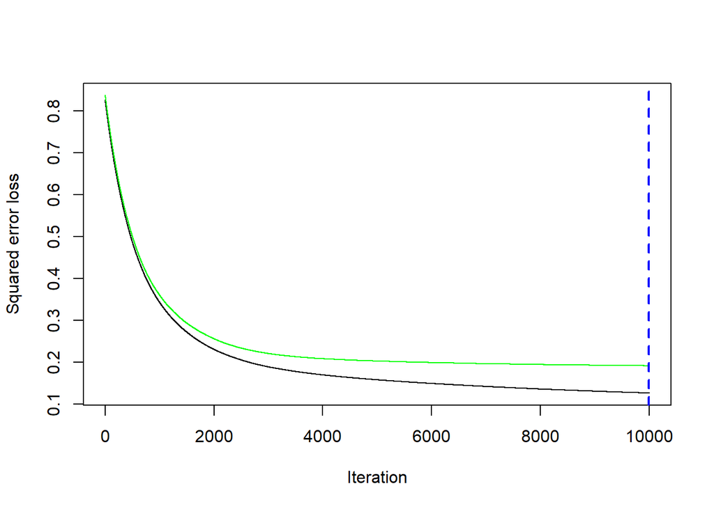

```
## [1] 9991
```

```r
gbm.perf(gbm_1, method = 'cv')
```

Use different hyper-parameters and create another model

```r
set.seed(123)
gbm_2 <- gbm::gbm(formula = Log_Salary ~ . - Salary,
        distribution = 'gaussian',
        data = train,
        n.trees = 10000,
        interaction.depth = 3,
        shrinkage = 0.1,
        cv.folds = 5,
        n.cores = NULL,
        verbose = F)

gbm_2$cv.error  # get MSE for every iteration
```

```
##     [1] 0.7239230 0.6313098 0.5645374 0.4977083 0.4444804 0.4075276 0.3741640
##     [8] 0.3461889 0.3214023 0.3036785 0.2865149 0.2739731 0.2599311 0.2507986
##    [15] 0.2435860 0.2355256 0.2280741 0.2232497 0.2183546 0.2146114 0.2114497
##    [22] 0.2087210 0.2057533 0.2033639 0.2007929 0.1989709 0.1970216 0.1970812
##    [29] 0.1965364 0.1969261 0.1964447 0.1949906 0.1952931 0.1965399 0.1951605
##    [36] 0.1962167 0.1960971 0.1968347 0.1966247 0.1957779 0.1952686 0.1942915
##    [43] 0.1952611 0.1939804 0.1930587 0.1905408 0.1904813 0.1901136 0.1899063
##    [50] 0.1901009 0.1894715 0.1906336 0.1908171 0.1908748 0.1911378 0.1907621
##    [57] 0.1906684 0.1915227 0.1921240 0.1934732 0.1925819 0.1917153 0.1913775
##    [64] 0.1921133 0.1918743 0.1930019 0.1926995 0.1922251 0.1926926 0.1922172
##    [71] 0.1916836 0.1926695 0.1902623 0.1896855 0.1889790 0.1892486 0.1890609
##    [78] 0.1872904 0.1885558 0.1888795 0.1895316 0.1888313 0.1881807 0.1896826
##    [85] 0.1898858 0.1901160 0.1904302 0.1904583 0.1912851 0.1905453 0.1918884
##    [92] 0.1919923 0.1920890 0.1925907 0.1926464 0.1924468 0.1930179 0.1938829
##    [99] 0.1933047 0.1933879 0.1930628 0.1936948 0.1927143 0.1923017 0.1922038
```

[output cut: 1414 more lines]

```r
min(gbm_2$cv.error)
```

```
## [1] 0.1872904
```

```r
sqrt(min(gbm_2$cv.error))  # compute RMSE
```

```
## [1] 0.4327706
```

Plot Loss Function as a result of n Trees added to the Ensemble

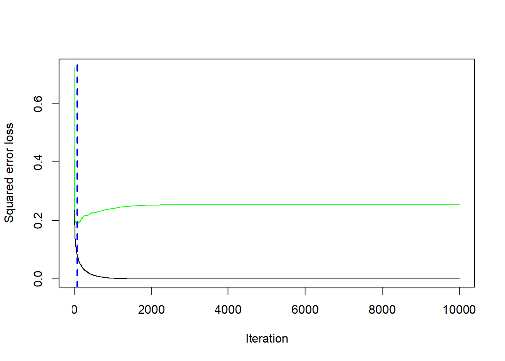

```
## [1] 78
```

```r
gbm.perf(gbm_2, method = 'cv')  # Overfitting
```

Tuning GBM hyper-parameters

Create hyper-parameter grid

```r
par_grid <- expand.grid(shrinkage = c(0.01, 0.1, 0.3),
            interaction_depth = c(1, 3, 5),
            n_minobsinnode = c(5, 10, 15),
            bag_fraction = c(0.5, 0.7, 0.9)  # Stochastic Gradient: bag.fraction < 1
            )  # generates all possible permutations of given parameters
par_grid
```

| shrinkage | interaction_depth | n_minobsinnode | bag_fraction |
| --- | --- | --- | --- |
| 0.01 | 1 | 5 | 0.5 |
| 0.10 | 1 | 5 | 0.5 |
| 0.30 | 1 | 5 | 0.5 |
| 0.01 | 3 | 5 | 0.5 |
| 0.10 | 3 | 5 | 0.5 |
| 0.30 | 3 | 5 | 0.5 |
| 0.01 | 5 | 5 | 0.5 |
| 0.10 | 5 | 5 | 0.5 |
| 0.30 | 5 | 5 | 0.5 |
| 0.01 | 1 | 10 | 0.5 |

[output cut: 71 more lines]

```r
nrow(par_grid)  # 81 different combinations
```

```
## [1] 81
```

Grid search with traditional approach (train and validation approach)

```r
for(i in 1:nrow(par_grid)){
    set.seed(123)
    gbm_tune <- gbm(formula = Log_Salary ~ . - Salary,
            distribution = 'gaussian',
            data = train,
            n.trees = 5000,
            interaction.depth = par_grid$interaction_depth[i],
            shrinkage = par_grid$shrinkage[i],
            n.minobsinnode = par_grid$n_minobsinnode[i],
            bag.fraction = par_grid$bag_fraction[i],
            train.fraction = 0.8,
            cv.folds = 0,
            n.cores = NULL,
            verbose = F)  # results are base on validation data
    par_grid$optimal_trees[i] <- which.min(gbm_tune$valid.error)  # which Tree is optimal Tree?
    par_grid$min_RMSE[i] <- sqrt(min(gbm_tune$valid.error))  # what is optimal Tree's RMSE?
}  # check 81 different Stochastic Gradient Boost models

head(par_grid)
```

|  | shrinkage | interaction_depth | n_minobsinnode | bag_fraction | optimal_trees | min_RMSE |
| --- | --- | --- | --- | --- | --- | --- |
| 1 | 0.01 | 1 | 5 | 0.5 | 265 | 0.6538571 |
| 2 | 0.10 | 1 | 5 | 0.5 | 28 | 0.6438596 |
| 3 | 0.30 | 1 | 5 | 0.5 | 6 | 0.6460779 |
| 4 | 0.01 | 3 | 5 | 0.5 | 163 | 0.6576012 |
| 5 | 0.10 | 3 | 5 | 0.5 | 14 | 0.6484788 |
| 6 | 0.30 | 3 | 5 | 0.5 | 5 | 0.6522096 |

```r
par_grid
```

| shrinkage | interaction_depth | n_minobsinnode | bag_fraction | optimal_trees | min_RMSE |
| --- | --- | --- | --- | --- | --- |
| 0.01 | 1 | 5 | 0.5 | 265 | 0.6538571 |
| 0.10 | 1 | 5 | 0.5 | 28 | 0.6438596 |
| 0.30 | 1 | 5 | 0.5 | 6 | 0.6460779 |
| 0.01 | 3 | 5 | 0.5 | 163 | 0.6576012 |
| 0.10 | 3 | 5 | 0.5 | 14 | 0.6484788 |
| 0.30 | 3 | 5 | 0.5 | 5 | 0.6522096 |
| 0.01 | 5 | 5 | 0.5 | 138 | 0.6660695 |
| 0.10 | 5 | 5 | 0.5 | 14 | 0.6655502 |
| 0.30 | 5 | 5 | 0.5 | 4 | 0.6757474 |
| 0.01 | 1 | 10 | 0.5 | 265 | 0.6554265 |

[output cut: 71 more lines]

```r
par_grid$optimal_trees
```

```
##  [1]  265   28    6  163   14    5  138   14    4  265   28    6  163   14    5
## [16]  157   14    4  265   25    6  172   14    5  165   15    5  265   30    8
## [31]  172   16   95  147   13    4  283   23    8  172   16    6  145   15    5
## [46]  259   30    8  172   14    6  147   14    5  279 1601    8  171   15    5
## [61]  150   14    4  279   28    8  162   15    5  151   14    4  279   28    8
## [76]  173   15    6  150   15    5
```

```r
all(par_grid$optimal_trees < 5000)
```

```
## [1] TRUE
```

```r
par_grid[which.min(par_grid$min_RMSE),]  # the best model (best hyper-parameter combination) which has min(RMSE) on validation data
```

|  | shrinkage | interaction_depth | n_minobsinnode | bag_fraction | optimal_trees | min_RMSE |
| --- | --- | --- | --- | --- | --- | --- |
| 27 | 0.3 | 5 | 15 | 0.5 | 5 | 0.6331184 |

Final model (use the best hyper-parameter combination for main model creation)

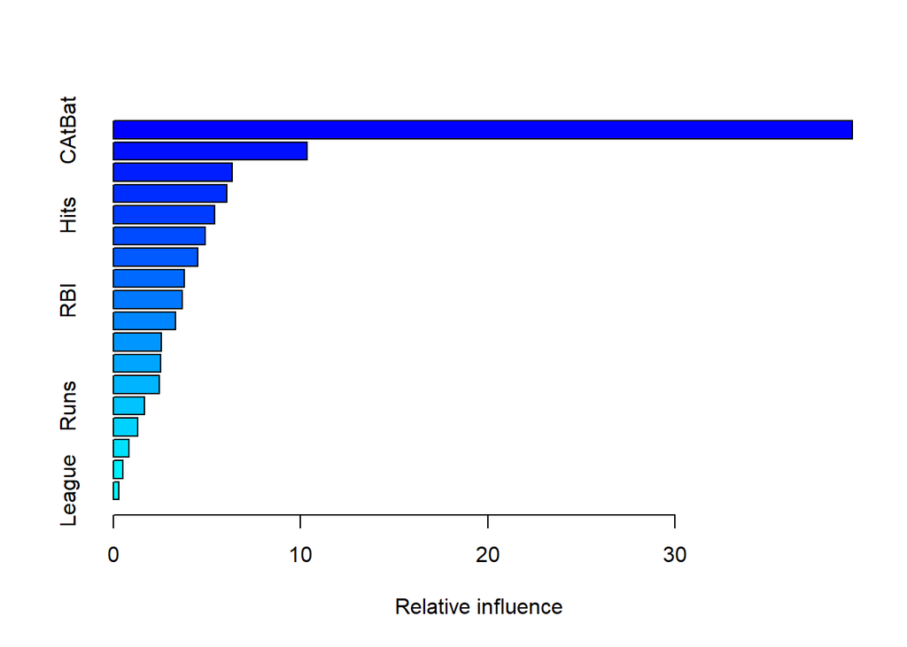

|  | var | rel.inf |
| --- | --- | --- |
| CAtBat | CAtBat | 39.4750338 |
| CRuns | CRuns | 10.3616750 |
| CRBI | CRBI | 6.3525817 |
| Walks | Walks | 6.0428462 |
| Hits | Hits | 5.4080666 |
| PutOuts | PutOuts | 4.9166199 |
| Years | Years | 4.4968276 |
| CWalks | CWalks | 3.7877250 |
| RBI | RBI | 3.6664404 |
| CHmRun | CHmRun | 3.3308594 |

[output cut: 8 more lines]

```r
gbm_3 <- gbm(formula = Log_Salary ~ . - Salary,
        distribution = 'gaussian',
        data = train,
        n.trees = 100,
        interaction.depth = 5,
        shrinkage = 0.3,
        n.minobsinnode = 15,
        bag.fraction = 0.5,
        train.fraction = 1,
        cv.folds = 0,
        n.cores = NULL)
summary(gbm_3)  # relative importance
```

## 6.2 Model 12: eXtreme Gradient Boost Regression (XGBoost Regression)

Create model.matrix on Train dataset

```r
x <- model.matrix(Log_Salary ~ . - Salary, data = train)[,-1]  # remove intercept
y <- train$Log_Salary

set.seed(123)
xgb_1 <- xgboost::xgboost(data = x,
            label = y,
            eta = 0.1,
            lambda = 0,
            max_depth = 8,
            nround = 1000,
            subsample = 0.65,
            objective = 'reg:squarederror',
            verbose = 0)

xgb_1$evaluation_log  # train RMSE
```

| iter | train_rmse |
| --- | --- |
| 1 | 4.9687135172 |
| 2 | 4.4733937706 |
| 3 | 4.0244684774 |
| 4 | 3.6237981204 |
| 5 | 3.2629836193 |
| 6 | 2.9388772011 |
| 7 | 2.6496346646 |
| 8 | 2.3862373603 |
| 9 | 2.1502806732 |
| 10 | 1.9379181011 |

[output cut: 990 more lines]

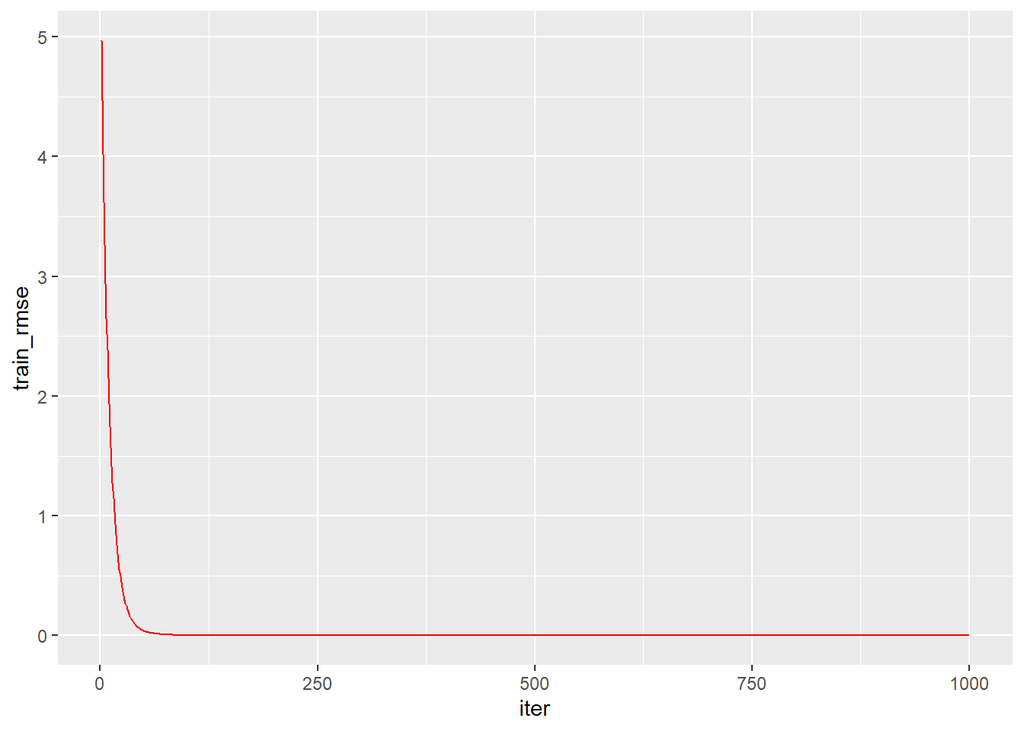

```r
ggplot(xgb_1$evaluation_log) +
    geom_line(aes(iter, train_rmse), color = 'red')  # plot error vs. number of trees
```

Tuning hyper-parameters

divide Train dataset to train and validation

```r
set.seed(1234)
train_cases <- sample(1:nrow(train), nrow(train) * 0.8)
train_xgboost <- train[train_cases,]  # train dataset
dim(train_xgboost)
```

```
## [1] 168  20
```

```r
xtrain <- model.matrix(Log_Salary ~ . - Salary, data = train_xgboost)[,-1]  # remove intercept
ytrain <- train_xgboost$Log_Salary

validation_xgboost <- train[- train_cases,]  # validation dataset
dim(validation_xgboost)
```

```
## [1] 42 20
```

```r
xvalidation <- model.matrix(Log_Salary ~ . - Salary, data = validation_xgboost)[, -1]  # remove intercept
yvalidation <- validation_xgboost$Log_Salary
```

Create hyper-parameter grid

```r
par_grid <- expand.grid(eta = c(0.01, 0.05, 0.1, 0.3),
            lambda = c(0, 1, 2, 5),
            max_depth = c(1, 3, 5, 7),
            subsample = c(0.65, 0.8, 1),
            colsample_bytree = c(0.8, 0.9, 1))
dim(par_grid)  # 576 different combination
```

```
## [1] 576   5
```

Grid search

```r
for(i in 1:nrow(par_grid)){
    set.seed(123)
    xgb_tune <- xgboost(data = xtrain,
            label = ytrain,
            eta = par_grid$eta[i],
            max_depth = par_grid$max_depth[i],
            subsample = par_grid$subsample[i],
            colsample_bytree = par_grid$colsample_bytree[i],
            nrounds = 1000,
            objective = 'reg:squarederror',
            verbose = 0,
            early_stopping_rounds = 10)
    pred_xgb_validation <- predict(xgb_tune, xvalidation)
    rmse <- sqrt(mean((yvalidation - pred_xgb_validation) ^ 2))
    par_grid$RMSE[i] <- rmse
}

par_grid
```

| eta | lambda | max_depth | subsample | colsample_bytree | RMSE |
| --- | --- | --- | --- | --- | --- |
| 0.01 | 0 | 1 | 0.65 | 0.8 | 0.6266264 |
| 0.05 | 0 | 1 | 0.65 | 0.8 | 0.6109503 |
| 0.10 | 0 | 1 | 0.65 | 0.8 | 0.6161736 |
| 0.30 | 0 | 1 | 0.65 | 0.8 | 0.6619974 |
| 0.01 | 1 | 1 | 0.65 | 0.8 | 0.6266264 |
| 0.05 | 1 | 1 | 0.65 | 0.8 | 0.6109503 |
| 0.10 | 1 | 1 | 0.65 | 0.8 | 0.6161736 |
| 0.30 | 1 | 1 | 0.65 | 0.8 | 0.6619974 |
| 0.01 | 2 | 1 | 0.65 | 0.8 | 0.6266264 |
| 0.05 | 2 | 1 | 0.65 | 0.8 | 0.6109503 |

[output cut: 566 more lines]

> We choose which one has min(RMSE)

Final model

```r
set.seed(123)
xgb_2 <- xgboost(data = x,
        label = y,
        eta = 0.05,
        max_depth = 3,
        lambda = 0,
        nround = 1000,
        colsample_bytree = 1,
        subsample = 0.8,
        objective = 'reg:squarederror',
        verbose = 0)
```

# 7 Model Evaluation

## 7.1 Test the Model 11 performance

### 7.1.1 Prediction

```r
pred_gbm <- predict(gbm_3, n.trees = 100, newdata = test)  # prediction on test dataset
pred_gbm  # predictions of Log_Salary
```

```
##  [1] 5.977080 6.496454 5.909876 4.895779 6.807751 4.513826 4.677650 5.385486
##  [9] 5.895907 7.482406 4.877476 6.682631 6.269659 5.749357 6.433297 5.941326
## [17] 6.764538 5.439777 6.530151 5.564699 6.586115 6.878480 4.888706 4.422310
## [25] 5.826527 5.671791 6.707924 5.552279 5.179300 5.965158 6.928703 6.640105
## [33] 4.546874 6.172582 6.155727 6.960714 6.845489 6.489244 6.405480 4.806251
## [41] 5.729489 6.342280 6.517620 6.091039 5.231674 5.608427 6.650968 5.027317
## [49] 6.234648 5.533116 6.249840 4.999097 6.697147
```

```r
pred_gbm <- exp(pred_gbm)
pred_gbm  # predictions of Salary
```

```
##  [1]  394.28742  662.78707  368.66062  133.72415  904.83380   91.27037
##  [7]  107.51716  218.21613  363.54639 1776.51061  131.29891  798.41660
## [13]  528.29700  313.98878  622.22183  380.43889  866.56576  230.39087
## [19]  685.50162  261.04665  724.95887  971.14957  132.78169   83.28848
## [25]  339.17879  290.55436  818.86904  257.82453  177.55850  389.61447
## [31] 1021.16839  765.17527   94.33708  479.42218  471.40947 1054.38615
## [37]  939.63263  658.02598  605.15234  122.27239  307.81187  568.09036
## [43]  676.96530  441.88013  187.10580  272.71484  773.53243  152.52317
## [49]  510.12113  252.93074  517.93012  148.27920  810.09111
```

### 7.1.2 Evaluate model performance in Test dataset:

Actual vs. Prediction

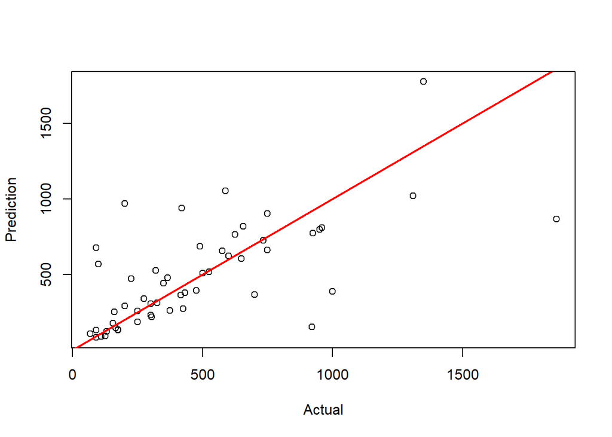

```r
plot(test$Salary, pred_gbm, xlab = "Actual", ylab = "Prediction")
abline(a = 0, b = 1, col = "red", lwd = 2)  # compare with 45' line
```

Absolute Error mean, median, sd, max, min

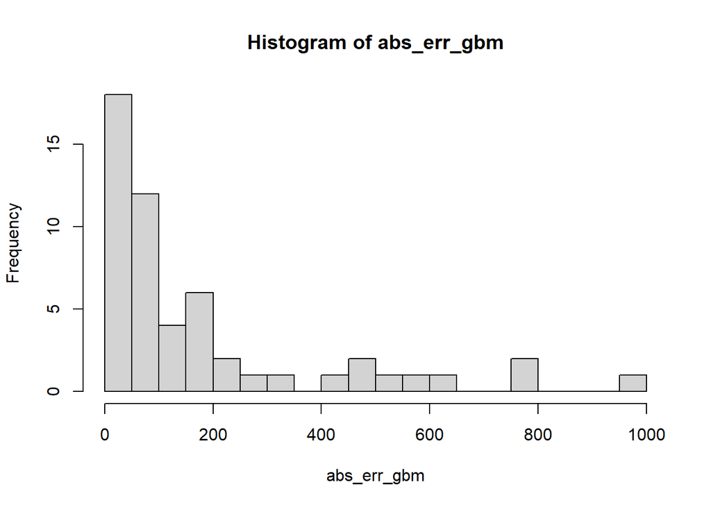

```r
abs_err_gbm <- abs(pred_gbm - test$Salary) #absolute error value (AEV)

hist(abs_err_gbm, breaks = 25)  # residuals distribution
```

```r
mean(abs_err_gbm)
```

```
## [1] 178.7554
```

```r
median(abs_err_gbm)
```

```
## [1] 87.21293
```

```r
sd(abs_err_gbm)
```

```
## [1] 227.5806
```

```r
max(abs_err_gbm)
```

```
## [1] 994.8942
```

```r
min(abs_err_gbm)
```

```
## [1] 6.711523
```

Boxplot (which observations are outliers?)

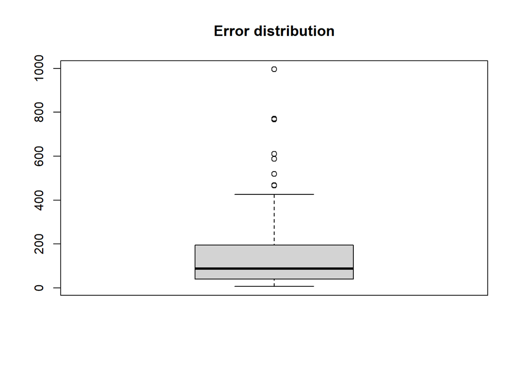

```r
boxplot(abs_err_gbm, main = 'Error distribution')
```

```r
models_comp <- rbind(models_comp, "GBReg" = c(mean(abs_err_gbm),
                                                 median(abs_err_gbm),
                                                 sd(abs_err_gbm),
                                                 IQR(abs_err_gbm),
                                                 range(abs_err_gbm)))

models_comp
```

|  | Mean.of.AbsErrors | Median.of.AbsErrors | SD.of.AbsErrors | IQR.of.AbsErrors | Min.of.AbsErrors | Max.of.AbsErrors |
| --- | --- | --- | --- | --- | --- | --- |
| LM | 237.4351 | 182.50553 | 220.8587 | 255.3140 | 0.08237289 | 831.5086 |
| BestSub | 246.9167 | 181.94126 | 237.4687 | 207.2769 | 0.90210710 | 945.0831 |
| BestSubCV | 233.5006 | 169.54492 | 233.3134 | 177.0159 | 2.31135988 | 935.5373 |
| TrimmedBestSub | 242.5957 | 172.51170 | 235.7795 | 252.5046 | 2.14943889 | 847.3258 |
| RidgeReg | 230.0030 | 178.81646 | 214.6858 | 191.6049 | 0.72885058 | 954.1922 |
| LassoReg | 230.9978 | 177.42153 | 217.7706 | 200.2234 | 1.06816078 | 886.1813 |
| Tree | 175.9590 | 105.21982 | 223.3094 | 155.8417 | 2.89664460 | 1008.8370 |
| Bagging | 154.0088 | 94.09638 | 164.9296 | 179.6082 | 9.59352167 | 691.4755 |
| RandomForrest | 155.8127 | 121.35808 | 164.5489 | 198.9246 | 3.06035932 | 732.3752 |
| TrimmedBagging | 168.5075 | 89.07238 | 199.3428 | 210.9390 | 6.52393551 | 910.0152 |

[output cut: 1 more lines]

## 7.2 Test the Model 12 performance

```r
x_test <- model.matrix(Log_Salary ~ . - Salary, data = test)[,-1]  # model.matrix of predictor variables
```

### 7.2.1 Prediction

```r
pred_xgb <- predict(xgb_2, x_test)  # prediction on test dataset
pred_xgb  # predictions of Log_Salary
```

```
##  [1] 6.180317 6.477949 6.367895 4.624417 6.350527 4.740881 4.205823 5.471660
##  [9] 5.754346 6.829147 4.712407 6.813131 6.135664 6.243953 6.621346 5.817489
## [17] 7.266074 5.416766 6.562365 5.491581 6.484967 6.816164 5.007344 4.755246
## [25] 5.789210 5.823238 6.701182 6.221922 5.042432 6.489076 6.909037 6.537189
## [33] 4.532753 6.478722 6.305456 6.766629 6.862512 6.387470 6.190369 4.694594
## [41] 5.720365 6.710404 6.632600 5.999749 5.114422 5.703022 6.660386 7.404523
## [49] 6.056671 5.415063 6.140253 5.000432 7.083910
```

```r
pred_xgb <- exp(pred_xgb)
pred_xgb  # predictions of Salary
```

```
##  [1]  483.14505  650.63491  582.82948  101.94335  572.79438  114.53511
##  [7]   67.07581  237.85462  315.55922  924.40183  111.31980  909.71454
## [13]  462.04556  514.88997  750.95484  336.12687 1430.92187  225.14985
## [19]  707.94371  242.64051  655.21718  912.47760  149.50715  116.19225
## [25]  326.75489  338.06490  813.36695  503.67056  154.84619  657.91495
## [31] 1001.28218  690.34297   93.01432  651.13832  547.55104  868.37942
## [37]  955.76459  594.35083  488.02622  109.35444  305.01610  820.90215
## [43]  759.45442  403.32762  166.40455  299.77209  780.85198 1643.40058
## [49]  426.95181  224.76668  464.17080  148.47736 1192.62199
```

### 7.2.2 Evaluate model performance in Test dataset:

Actual vs. Prediction

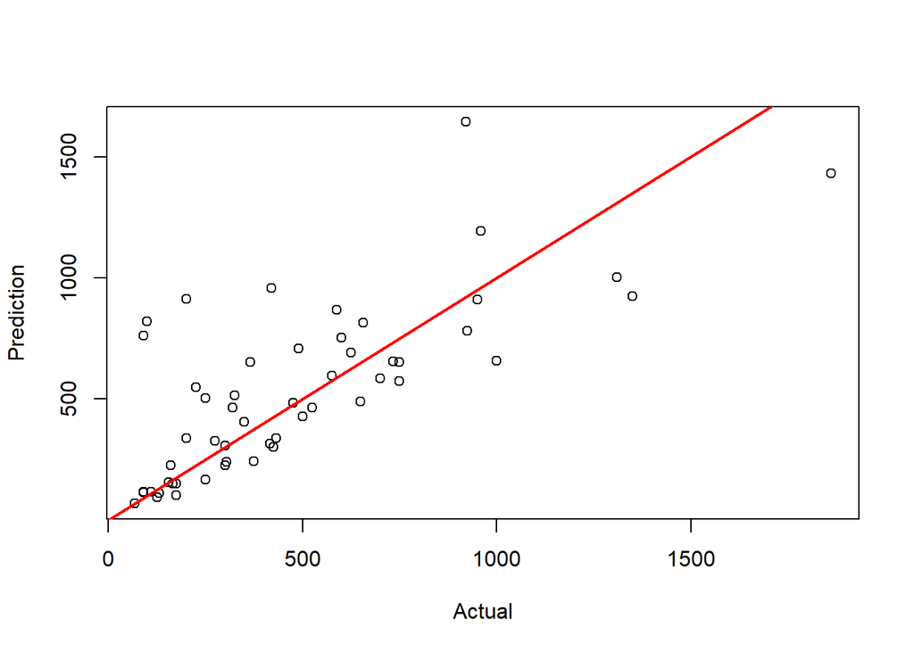

```r
plot(test$Salary, pred_xgb, xlab = "Actual", ylab = "Prediction")
abline(a = 0, b = 1, col = "red", lwd = 2)  # compare with 45' line
```

Absolute Error mean, median, sd, max, min

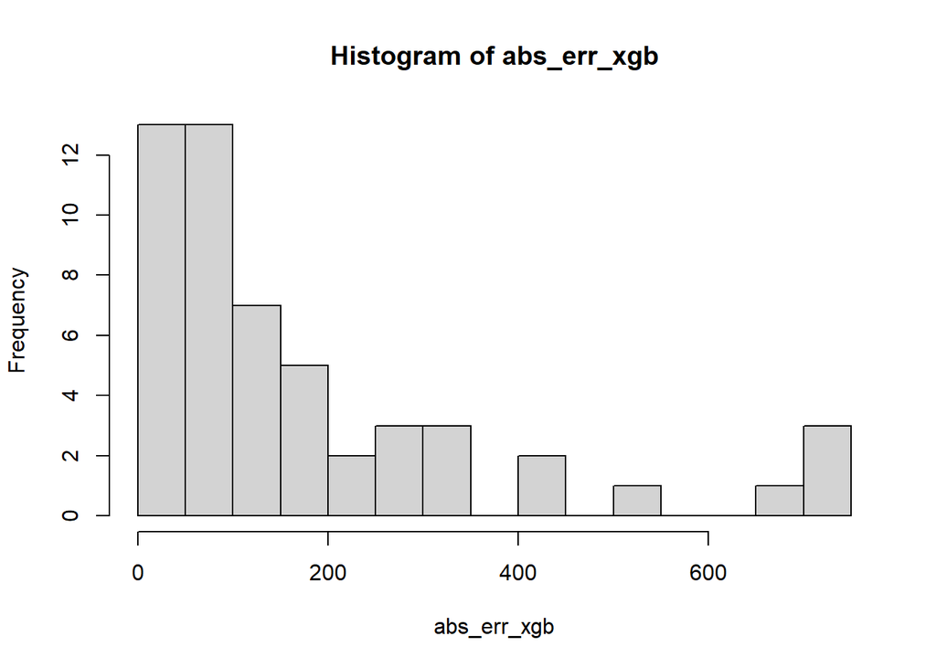

```r
abs_err_xgb <- abs(pred_xgb - test$Salary) #absolute error value (AEV)

hist(abs_err_xgb, breaks = 25)  # residuals distribution
```

```r
mean(abs_err_xgb)
```

```
## [1] 176.6019
```

```r
median(abs_err_xgb)
```

```
## [1] 101.1078
```

```r
sd(abs_err_xgb)
```

```
## [1] 194.9715
```

```r
max(abs_err_xgb)
```

```
## [1] 723.4006
```

```r
min(abs_err_xgb)
```

```
## [1] 0.153809
```

Boxplot (which observations are outliers?)

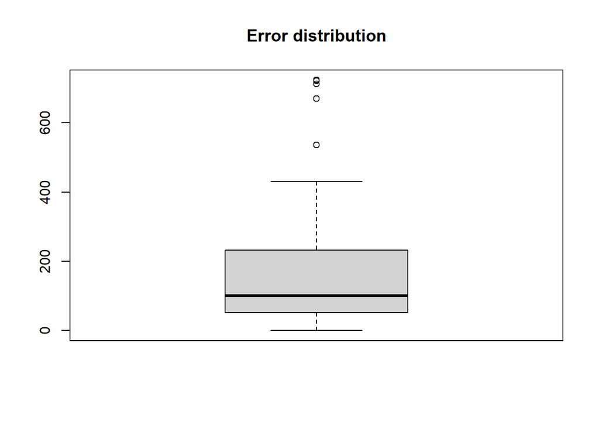

```r
boxplot(abs_err_xgb, main = 'Error distribution')
```

```r
models_comp <- rbind(models_comp, "XGBReg" = c(mean(abs_err_xgb),
                                                 median(abs_err_xgb),
                                                 sd(abs_err_xgb),
                                                 IQR(abs_err_xgb),
                                                 range(abs_err_xgb)))

models_comp
```

|  | Mean.of.AbsErrors | Median.of.AbsErrors | SD.of.AbsErrors | IQR.of.AbsErrors | Min.of.AbsErrors | Max.of.AbsErrors |
| --- | --- | --- | --- | --- | --- | --- |
| LM | 237.4351 | 182.50553 | 220.8587 | 255.3140 | 0.08237289 | 831.5086 |
| BestSub | 246.9167 | 181.94126 | 237.4687 | 207.2769 | 0.90210710 | 945.0831 |
| BestSubCV | 233.5006 | 169.54492 | 233.3134 | 177.0159 | 2.31135988 | 935.5373 |
| TrimmedBestSub | 242.5957 | 172.51170 | 235.7795 | 252.5046 | 2.14943889 | 847.3258 |
| RidgeReg | 230.0030 | 178.81646 | 214.6858 | 191.6049 | 0.72885058 | 954.1922 |
| LassoReg | 230.9978 | 177.42153 | 217.7706 | 200.2234 | 1.06816078 | 886.1813 |
| Tree | 175.9590 | 105.21982 | 223.3094 | 155.8417 | 2.89664460 | 1008.8370 |
| Bagging | 154.0088 | 94.09638 | 164.9296 | 179.6082 | 9.59352167 | 691.4755 |
| RandomForrest | 155.8127 | 121.35808 | 164.5489 | 198.9246 | 3.06035932 | 732.3752 |
| TrimmedBagging | 168.5075 | 89.07238 | 199.3428 | 210.9390 | 6.52393551 | 910.0152 |

[output cut: 2 more lines]

For more information check the [Github](https://github.com/mamomen1996/R_CS_06) repository.